# PhaseNet smoke test — 2019 Ridgecrest

Runs a PhaseNet weight set over five SCSN stations around the 2019 Ridgecrest sequence and checks the picks against the waveforms.

The question this answers: **do the picks land on real arrivals, in the right order, with moveout that matches distance?** It is a sanity check you can run on a laptop in about two minutes, not a benchmark.

Two events are used, deliberately:

| Event | Why |
| --- | --- |
| **M7.1 mainshock**, 2019-07-06 03:19:53 UTC | Strong signal everywhere; good for the record section |
| **M4.6 aftershock**, 2019-07-06 08:32:58 UTC | Short, impulsive source — the honest test of S picking |

A magnitude 7 ruptures for tens of seconds, so at these distances its S arrival is buried inside ongoing rupture radiation and pickers routinely miss it. That is expected behaviour rather than a broken setup, which is why the S−P timing check below uses the moderate aftershock instead.

Data comes from the SCEDC public S3 bucket (`scedc-pds`) over anonymous access — no AWS credentials required.

```python
import io

import matplotlib.pyplot as plt
import numpy as np
import obspy
import pandas as pd
import seisbench.models as sbm
from obspy import UTCDateTime
from obspy.geodetics import gps2dist_azimuth
from s3fs import S3FileSystem

%matplotlib inline
```

## 1. Configuration

```python
# --- Events (USGS catalog) --------------------------------------------------
# Both fall on 2019 day-of-year 187, so they share the same SCEDC day files.
MAINSHOCK = dict(
    name="M7.1 mainshock",
    time=UTCDateTime("2019-07-06T03:19:53.040000Z"),
    lat=35.770, lon=-117.599, depth_km=8.0,
)
AFTERSHOCK = dict(
    name="M4.6 aftershock",
    time=UTCDateTime("2019-07-06T08:32:57.550000Z"),
    lat=35.639, lon=-117.491, depth_km=3.1,
)

YEAR, DOY = 2019, 187

# --- Stations: CI (SCSN), all verified present in SCEDC on this day --------
STATIONS = [
    ("CLC",  35.8157, -117.5975),
    ("TOW2", 35.8086, -117.7649),
    ("SRT",  35.6923, -117.7505),
    ("WRC2", 35.9479, -117.6504),
    ("JRC2", 35.9825, -117.8089),
]

NETWORK, CHANNEL = "CI", "HH"      # broadband, 100 Hz
P_THRESHOLD = S_THRESHOLD = 0.3
VP, VS = 6.0, 3.5                  # crustal averages for reference curves

# Categorical colors, CVD-validated. Phase is also encoded by linestyle and
# text label, so identity never depends on color alone.
C_P, C_S = "#2a78d6", "#eb6834"


def distance_km(event, lat, lon):
    return gps2dist_azimuth(event["lat"], event["lon"], lat, lon)[0] / 1000.0
```

## 2. Data access

SCEDC stores one whole-day miniSEED file per channel (~20 MB), so each event costs roughly 300 MB of download and a minute or so on a warm connection. Streams are trimmed to the event window immediately.

```python
def scedc_key(sta, comp, net=NETWORK, cha=CHANNEL, year=YEAR, doy=DOY, loc=""):
    """Build an SCEDC S3 object key.

    The SCEDC layout differs from NCEDC - the network is not a directory, the
    day folder uses an underscore, and the station is padded to five characters:

        scedc-pds/continuous_waveforms/<year>/<year>_<doy>/
        <net><sta:_<5><cha><comp><loc:_<3><year><doy>.ms

    e.g. CICLC__HHZ___2019187.ms
    """
    base = f"{net}{sta.ljust(5, '_')}{cha}{comp}{loc.ljust(3, '_')}{year}{doy:03d}.ms"
    return f"scedc-pds/continuous_waveforms/{year}/{year}_{doy:03d}/{base}"


def load_event(fs, event, pre=30, post=120):
    """Fetch every station for one event, trimmed to its time window."""
    out = {}
    for sta, lat, lon in STATIONS:
        st = obspy.Stream()
        for comp in "ZNE":
            try:
                with fs.open(scedc_key(sta, comp)) as fh:
                    st += obspy.read(io.BytesIO(fh.read()))
            except FileNotFoundError:
                print(f"  {sta} {comp}: not found")
            except Exception as exc:
                print(f"  {sta} {comp}: {type(exc).__name__}")
        if len(st) == 0:
            print(f"  {sta}: no data, skipping")
            continue
        st.merge(fill_value=0)                       # close gaps into one trace
        st.trim(event["time"] - pre, event["time"] + post)
        if len(st):
            out[sta] = st
    return out


def pick_all(model, streams):
    picks = {}
    for sta, st in streams.items():
        out = model.classify(st, P_threshold=P_THRESHOLD, S_threshold=S_THRESHOLD)
        picks[sta] = list(out.picks)
    return picks
```

## 3. Load the picker

`original` is the published Zhu & Beroza (2019) PhaseNet. If the QuakeScope 2026 weights (`quakescope2026`) have been converted and installed locally they are used instead — see `sb_catalog/models/phasenet/README.md` for that step.

```python
WEIGHT = "quakescope2026" if "quakescope2026" in sbm.PhaseNet.list_pretrained() else "original"

if WEIGHT == "original":
    print("quakescope2026 not installed - using published 'original' weights")
    print("  (convert with sb_catalog/models/phasenet/convert_checkpoint.py)")

model = sbm.PhaseNet.from_pretrained(WEIGHT)
print(f"\nWeight set : {WEIGHT}")
print(f"Input      : {model.in_samples} samples @ {model.sampling_rate:g} Hz")
```

```
Weight set : quakescope2026
Input      : 3001 samples @ 100 Hz
```

## 4. Mainshock — picks on the waveforms

Each pick should sit on the onset of visible energy: P on the first break, clearest on the vertical; S on the later, larger arrival, clearest on the horizontals.

```python
fs = S3FileSystem(anon=True)

print(f"Fetching {MAINSHOCK['name']} ...")
main_streams = load_event(fs, MAINSHOCK)
main_picks = pick_all(model, main_streams)

print(f"\n{len(main_streams)}/{len(STATIONS)} stations loaded\n")
for sta, pk in main_picks.items():
    n_p = sum(1 for p in pk if p.phase == 'P')
    n_s = sum(1 for p in pk if p.phase == 'S')
    print(f"  {sta:<6} {len(pk):3d} picks  (P={n_p}, S={n_s})")
```

```
Fetching M7.1 mainshock ...
```

```
5/5 stations loaded

  CLC      6 picks  (P=4, S=2)
  TOW2     6 picks  (P=5, S=1)
  SRT      4 picks  (P=3, S=1)
  WRC2     9 picks  (P=5, S=4)
  JRC2     8 picks  (P=5, S=3)
```

```python
def plot_station(sta, st, sta_picks, dist, event, window=(-5, 40)):
    fig, axes = plt.subplots(3, 1, figsize=(12, 5.5), sharex=True)
    for ax, comp in zip(axes, "ZNE"):
        tr = st.select(component=comp)
        ax.set_ylabel(f"{CHANNEL}{comp}", fontsize=9)
        ax.grid(alpha=0.25, lw=0.5)
        ax.tick_params(labelsize=9)
        if not tr:
            continue
        tr = tr[0]
        ax.plot(tr.times(reftime=event["time"]), tr.data, color="#3d3d3d", lw=0.6)
        for p in sta_picks:
            dt = p.peak_time - event["time"]
            if not (window[0] <= dt <= window[1]):
                continue
            is_p = p.phase == "P"
            ax.axvline(dt, color=C_P if is_p else C_S, lw=1.6,
                       ls="-" if is_p else "--", alpha=0.9)

    for p in sta_picks:
        dt = p.peak_time - event["time"]
        if window[0] <= dt <= window[1]:
            axes[0].annotate(p.phase, (dt, 1.03), xycoords=("data", "axes fraction"),
                             ha="center", fontsize=9,
                             color=C_P if p.phase == "P" else C_S)

    handles = [plt.Line2D([], [], color=C_P, lw=1.6, ls="-", label="P"),
               plt.Line2D([], [], color=C_S, lw=1.6, ls="--", label="S")]
    axes[0].legend(handles=handles, loc="upper right", fontsize=9,
                   frameon=False, ncol=2)
    axes[0].set_title(f"{NETWORK}.{sta}  -  {dist:.1f} km  -  {event['name']}",
                      fontsize=11, loc="left")
    axes[-1].set_xlim(*window)
    axes[-1].set_xlabel("Seconds after origin time")
    fig.tight_layout()
    return fig
```

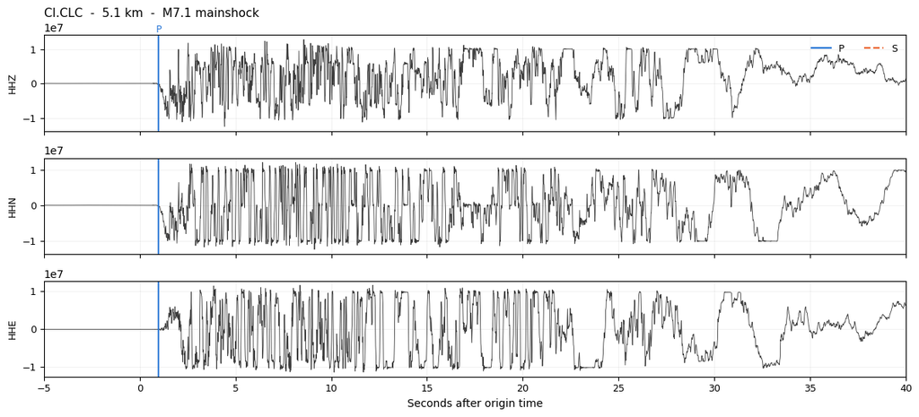

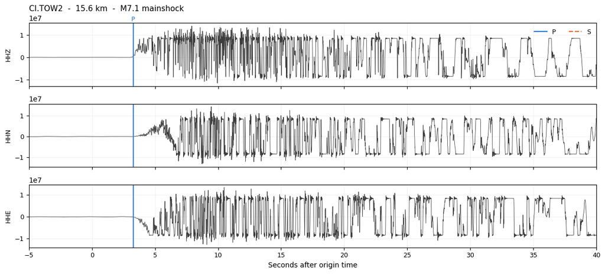

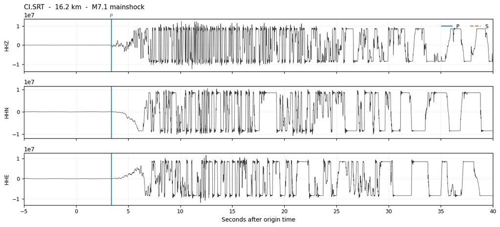

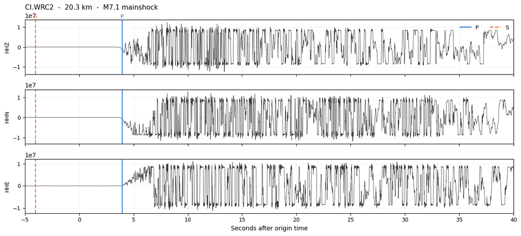

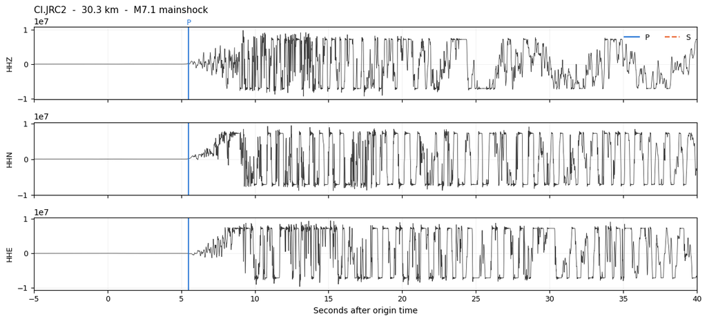

```python
for sta, st in main_streams.items():
    lat, lon = next((la, lo) for c, la, lo in STATIONS if c == sta)
    plot_station(sta, st, main_picks[sta],
                 distance_km(MAINSHOCK, lat, lon), MAINSHOCK)
    plt.show()
```

### Record section

Traces ordered by distance. Real arrivals form a coherent moveout, so picks should follow the reference curves rather than scattering.

```python
def record_section(streams, picks, event, window=(-5, 45), gain=3.0):
    fig, ax = plt.subplots(figsize=(11, 6))
    dmax = 0
    for sta, st in streams.items():
        lat, lon = next((la, lo) for c, la, lo in STATIONS if c == sta)
        d = distance_km(event, lat, lon)
        dmax = max(dmax, d)
        tr = st.select(component="Z")
        if not tr:
            continue
        tr = tr[0]
        x = tr.data.astype(float)
        peak = np.abs(x).max()
        if peak > 0:
            x = x / peak * gain
        ax.plot(tr.times(reftime=event["time"]), x + d, color="#3d3d3d", lw=0.5)
        ax.annotate(sta, (window[0] + 0.5, d + 0.8), fontsize=9, color="#52514e")
        for p in picks[sta]:
            dt = p.peak_time - event["time"]
            if not (window[0] <= dt <= window[1]):
                continue
            is_p = p.phase == "P"
            ax.plot([dt, dt], [d - gain * 0.8, d + gain * 0.8],
                    color=C_P if is_p else C_S, lw=1.8,
                    ls="-" if is_p else "--")

    dd = np.linspace(0, dmax * 1.1, 60)
    hyp = np.hypot(dd, event["depth_km"])
    ax.plot(hyp / VP, dd, color=C_P, lw=1, alpha=0.45)
    ax.plot(hyp / VS, dd, color=C_S, lw=1, alpha=0.45, ls="--")

    handles = [
        plt.Line2D([], [], color=C_P, lw=1.8, ls="-", label="P pick"),
        plt.Line2D([], [], color=C_S, lw=1.8, ls="--", label="S pick"),
        plt.Line2D([], [], color="#8a8a8a", lw=1,
                   label=f"predicted (Vp {VP}, Vs {VS} km/s)"),
    ]
    ax.legend(handles=handles, loc="lower right", fontsize=9, frameon=False)
    ax.set_xlim(*window)
    ax.set_ylim(-gain, dmax * 1.15)
    ax.set_xlabel("Seconds after origin time")
    ax.set_ylabel("Epicentral distance (km)")
    ax.set_title(f"Record section - vertical component - {event['name']}",
                 fontsize=11, loc="left")
    ax.grid(alpha=0.25, lw=0.5)
    fig.tight_layout()
    return fig
```

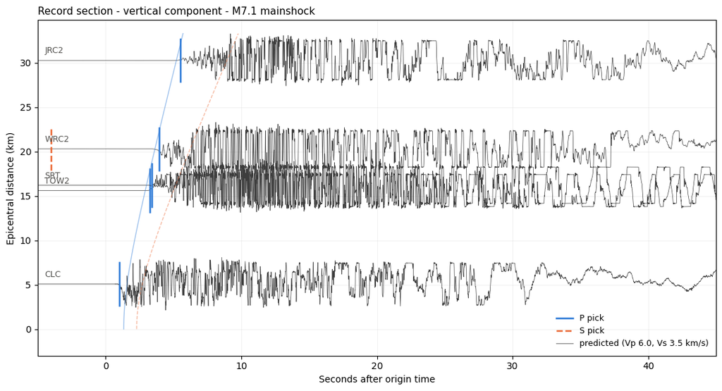

```python
record_section(main_streams, main_picks, MAINSHOCK)
plt.show()
```

## 5. Aftershock — S−P timing check

The moderate aftershock has a short, impulsive source, so both phases should be picked cleanly. Observed S−P is compared against the interval implied by hypocentral distance.

An S is only paired with a P when it falls within a plausible interval of it — otherwise the next S in an active aftershock sequence can easily belong to a different earthquake.

```python
print(f"Fetching {AFTERSHOCK['name']} ...")
after_streams = load_event(fs, AFTERSHOCK, pre=30, post=90)
after_picks = pick_all(model, after_streams)
print(f"\n{len(after_streams)}/{len(STATIONS)} stations loaded")
```

```
Fetching M4.6 aftershock ...
```

```
5/5 stations loaded
```

```python
def first_arrivals(sta_picks, event, dist, max_ratio=2.5, pad=3.0):
    """First P after origin, and the first S that could belong to the same event.

    An S is only accepted if it lands within a physically plausible interval of
    the P. Without that guard the "next S after the P" can easily belong to a
    later aftershock, which is a real hazard in this sequence.
    """
    hyp = np.hypot(dist, event["depth_km"])
    pred_sp = hyp / VS - hyp / VP

    ps = [p for p in sta_picks if p.phase == "P" and p.peak_time >= event["time"]]
    if not ps:
        return None, None, pred_sp
    p0 = min(ps, key=lambda p: p.peak_time)

    limit = pred_sp * max_ratio + pad
    ss = [s for s in sta_picks
          if s.phase == "S"
          and 0 < (s.peak_time - p0.peak_time) <= limit]
    s0 = min(ss, key=lambda s: s.peak_time) if ss else None
    return p0, s0, pred_sp
```

```python
rows = []
for sta, lat, lon in STATIONS:
    if sta not in after_picks:
        continue
    dist = distance_km(AFTERSHOCK, lat, lon)
    p0, s0, pred = first_arrivals(after_picks[sta], AFTERSHOCK, dist)
    obs = (s0.peak_time - p0.peak_time) if (p0 and s0) else np.nan
    rows.append(dict(
        station=sta,
        dist_km=round(dist, 1),
        P=round(p0.peak_time - AFTERSHOCK['time'], 2) if p0 else np.nan,
        S=round(s0.peak_time - AFTERSHOCK['time'], 2) if s0 else np.nan,
        obs_SP=round(obs, 2) if p0 and s0 else np.nan,
        pred_SP=round(pred, 2),
        diff=round(obs - pred, 2) if p0 and s0 else np.nan,
    ))

df = pd.DataFrame(rows)
print(df.to_string(index=False))

paired = df.dropna(subset=['obs_SP'])
print(f"\nStations with a P/S pair : {len(paired)}/{len(df)}")
if len(paired):
    print(f"S-P within 2 s of predicted : {int(paired['diff'].abs().lt(2).sum())}/{len(paired)}")
    print(f"P precedes S everywhere     : {bool((paired['S'] > paired['P']).all())}")
```

```
station  dist_km    P     S  obs_SP  pred_SP  diff
    CLC     21.8 3.92  6.99    3.07     2.63  0.44
   TOW2     31.1 5.97 10.81    4.84     3.72  1.12
    SRT     24.2 4.73  8.80    4.07     2.91  1.16
   WRC2     37.2 0.39  1.39    1.00     4.44 -3.44
   JRC2     47.7 8.43 14.57    6.14     5.69  0.45

Stations with a P/S pair : 5/5
S-P within 2 s of predicted : 4/5
P precedes S everywhere     : True
```

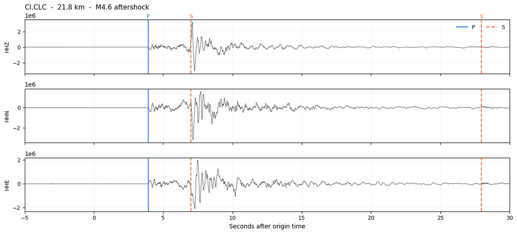

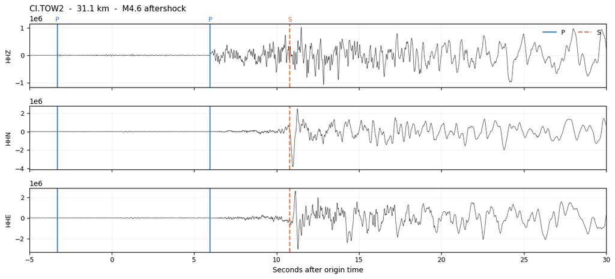

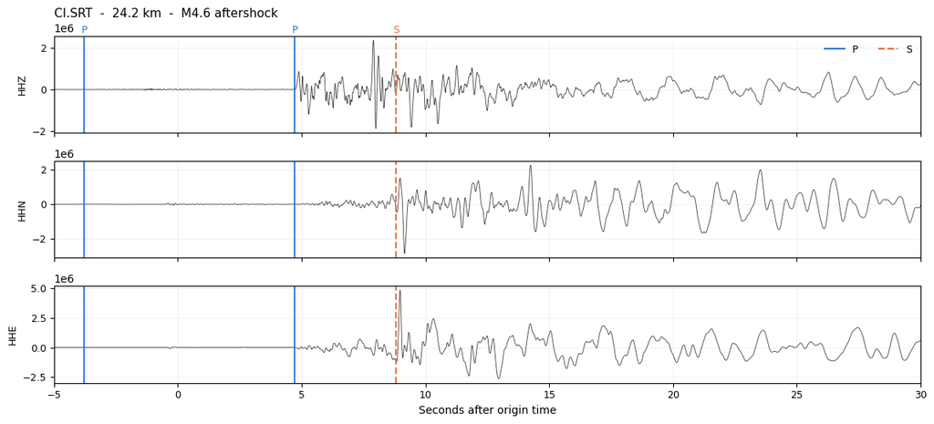

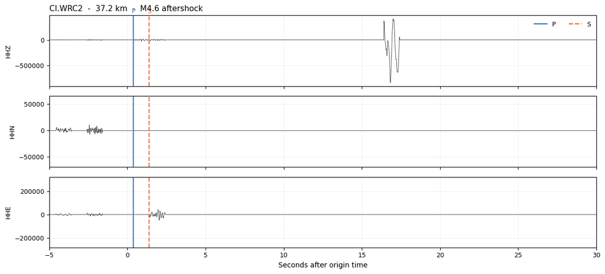

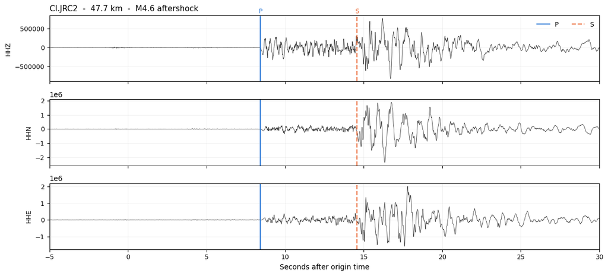

```python
for sta, st in after_streams.items():
    lat, lon = next((la, lo) for c, la, lo in STATIONS if c == sta)
    plot_station(sta, st, after_picks[sta],
                 distance_km(AFTERSHOCK, lat, lon), AFTERSHOCK, window=(-5, 30))
    plt.show()
```

## How to read the result

**The setup is healthy when** picks sit on visible onsets, P precedes S at every station, observed S−P grows with distance and tracks the prediction to within a second or two, and picks in the record section follow the moveout curves.

Observed S−P running slightly longer than predicted is normal — a single constant-velocity layer is a crude approximation, and the real Vp/Vs in this crust is a little higher than the 1.71 assumed here.

**Worth investigating** is S before P, S−P that does not scale with distance (often a component-mapping or resampling problem), dense picks in the pre-event noise, or a station that produces nothing while its neighbours at similar distance work.

Two things are expected rather than alarming: missing S for the mainshock at close range, and extra picks throughout — this window sits inside one of the most active aftershock sequences on record, so much of that extra energy is real earthquakes.